# Jazz-5

Saimanasvi Charugundla, Niyat Efrem, John Dato, Rim Wolde

2/17/2022

## **ABSTARCT:**

Our main question is “How has COVID-19 relief funding impacted society?”. We believe this question to be significant because through this research we can precisely see the impact of COVID-19 based on the amount of relief funding a certain location received. To address this question, we will be examining a dataset that covers the distribution of select relief funds, as well as comparing that to the impact it has had on healthcare providers.

## **KEYWORDS**

Healthcare, Economy, Coronavirus, Law

## **INTRODUCTION**

Since the start of the coronavirus pandemic, policies have been enacted to ease the financial pressure that hospitals and healthcare providers on the front lines have been going through with the increasing number of COVID-19 cases. Two acts that have provided relief funds for hospitals and front-line workers all over the country are the bipartisan CARES Act and the Paycheck Protection Program and Health Care Enhancement Act. The goal of these bills is to replenish the finances of hospitals around the country that have been drastically impacted. In total, they have provided $175 billion in funds and have been distributed in two rounds of payments to hospitals that have had an influx of patients with the virus. Our project analyzes the data represented in this dataset to better understand the effectiveness of the relief funds and to also have an understanding of how COVID-19 has impacted the healthcare system as well as the economy.

## **DESIGN SITUATION**

**Project Framing**: We are hoping to take this dataset and analyze the distribution of funding and compare it to the impact of COVID-19 to get a clear picture of the help that these healthcare providers received through the funds.

**Human Values**: The funding was given by the government through the CARES Act and the Paycheck Protection Program and Health Care Enhancement Act allows for security for all parts of healthcare systems such as the administration, hospitals, front-line workers, etc. Through these acts, the United States government is giving charity to different hospitals all over the country. The government is splitting up funds to each location depending on the number of cases in the area and with this, they are practicing equity.

**Direct Stakeholders**: The United States Government, the U.S. Department of Health and Human Services (HRSA), the Centers for Disease Control and Prevention (CDC), and hospitals that have received aid. The U.S. Government passed the two acts that provided funding for hospitals around the country. The HRSA is the department that has collected the data with the CDC being the organization that has federally funded this collection.

**Indirect Stakeholders**: Indirect Stakeholders would be individuals who were admitted into hospitals that received funding through the CARES Act and the Paycheck Protection Program and Health Care Enhancement Act as it would have helped the patients. Along with this, the front-line workers are also indirect stakeholders as they were given aid through the funding given to them.

**Benefits**: With the capacity and limits of hospitals and other healthcare systems being pushed to the brim, the received financial aid eased the stress and tension of front-line workers and saved the lives of individuals who were admitted into overpopulated hospitals. The Paycheck Protection Program and Health Care Enhancement Act provides $75 billion to support the need for COVID-19 related expenses and losses. This dataset also helps visualize which areas in the country got more funding compared to other areas. With this visualization we can analyze the distribution of funds and if it was done in an effective manner.

**Harms**: When a viewer takes a look at this dataset, they might mistake this dataset to be a record of the total amount of funding that these healthcare administrators had received, rather than just the amount of money that they received through these two Acts.

## **HOW COVID-19 IMPACTED THE HEALTHCARE SYSTEM**

1. How were relief funds decided during the pandemic, what were the criteria?
2. Which states had the most patients?
3. How has COVID-19 progressed over time?

The questions are important because during the era of the COVID-19 pandemic, while population health was affected by skyrocketing death rates, the economy was also an issue. There was a lack of finances in the healthcare system with the large influx of infected people. The motivation behind trying to find which states and cities were affected by the pandemic the most was to figure out how the resources can be better allocated. Within finding out what cities or states were affected most, one can investigate what about them caused such high rates, whether it be social inequity, poor financial standing, or merely the fact that policies were not enacted. This is important as it relates to the first questions about relief funds, in these states and/or cities that were affected the most, what were the criteria in determining the number of funds needed. Or vice versa, by seeing the distribution of funds to cities one can answer the question of which states were affected most.

## **THE DATASET CONCERN**

**SIZE AND COMPLEXITY**: This data set consists of 6 features (columns) and more than 200 observations (rows). The data is taken from a national scale of the United States of America.

## **DATA PROVENANCE:**

**Who or what is represented in the data?** The data represents the quantitative impact of the bipartisan CARES Act and the Paycheck Protection Program and Health Enhancement Act, by showing the number of funds given to hospitals around the nation. In terms of representation in the data, in an obvious sense, the hospitals who treated COVID-19 patients are represented as they were the ones who received the funds. In an analytical lens, this also represents the impact that COVID-19 had on the healthcare system, it represents the economic standing and need of these hospitals, which can be correlated to the financial standing of the states in which they are located.

**What is an observation? What variables are included (and excluded)?** An observation represents the case in which characteristics are being collected. A variable is what keys/attributes are being collected on these observations. In this sense, an observation would be the rows, which are the hospitals. The variables would be the columns which were: the hospital names, the city of the hospital, the state it is located in, the amount of money returned, the money given to them in the first round of allocation, and finally the amount of money given during the second round of allocation. The variables that were excluded would be the number of patients being treated at the specific time of allocation. Although all these hospitals had over 100 COVID-19 patients, it excludes the amount in each hospital specifically.

**Who collected the data? When? For what purpose? How was the data collection effort funded? Who is likely to benefit from the data or make money?** The U.S Department of Health and Human Services (HRSA), collected the data. In terms of who published the data, the data collection was funded federally through the CDC, which pays great attention to all aspects of the disease in the nation, including the economic impacts of the disease. This data was collected through both resource allocation periods which were throughout the year 2020, the data was lastly updated in November 2020. The purpose of collecting this data would be to represent the distribution of money and to also showcase the economic impact of COVID-19. Looking at the number of money hospitals needed to take care of patients, implies the severity of the disease. The people more likely to benefit from the data would be the government as they would be congratulated on giving money to hospitals in need. However, the recognition they would benefit doesn’t suggest that anyone would make money from this data set, in fact, the opposite.

**How was the data validated and held secure? Is it credible and trustworthy?** The data is validated in the terms that it came from a federal institution, it was data essentially created by the government, which in this society is taken to be validated because it would be coming from a primary source. The data was about government funds, and the data was recorded by the government, making it valid. In terms of credibility, it is posted on the CDC database which goes to show that it is true because the CDC is held to be one of the most respected research databases.

**How did you obtain the data? Do you credit the source of the data?** We obtained it through the “DATA.gov” website that the government has. The website contains datasets from a range of subjects. We selected the U.S. Department of Health which contained datasets concerning the health and well-being of Americans, ranging from emergency release funds to risk behavior in teens. After locating this data set, it led us to the CDC website, we were then able to download the data from there.

## **EXPECTED LIMITATIONS**

While it is hard to determine what is going to happen in the near future, our data gives us a small glimpse into what might possibly happen. We cannot exactly predict what happens today or in the future but having data helps us understand what could happen in the future and what we can do to prevent or enable something from happening. In the case of COVID-19 and our current situation, a good implication for most if not all of our policymakers is that they will continue to discuss and work with releasing funds to continue the financial assistance at hospitals as well as getting rid of COVID-19. For technologists, this might look a little different, as they will most likely continue to work and assist with pieces of technology that work with and around eradicating COVID-19. For designers, in which I’m assuming people like data scientists, will be working in the background but they have the most important role, in which they study the numbers, review trends, and observe what is happening. Without designers around doing their work and working with this type of data, it would be hard to follow trends and would make it a very hard time for scientists in other fields to understand the virus itself and how to combat it.

## **LIMITATIONS**

I think one limitation that is inevitable when working with data is trying to see if the data can answer all the questions we have. Is it sufficient enough to the point where our cases are made through our data and answers all the questions we face? Another limitation that could happen could possibly be underestimating the data and not really having it show what we want it to show. When it comes to policymakers, technologists, and designers, I think that they will also face some limitations. I expect limitations when it comes to their choices and studies working with COVID-19, as it is something that is already hard enough to work with so just trying to figure out how to get rid of it while also dealing with things like the reliability of data, the quality and even things as small as having your whole team is something that gets more difficult. In regards to our questions, I believe the only limitation would be again trying to answer those questions not with our words but with data.

## **ACKNOWLEDGEMENTS**

Our appreciation goes out to Professor David G. Hendry, for providing us with the support and opportunity to do extensive research on human well-being. In addition, we thank our Teaching Assistant, Akshita Gundavarapu who has provided us guidance throughout this project and shared their insight that helped in improving our research.

## **REFERENCES**

**Provider Relief Fund COVID-19 High-Impact Payments** “Provider Relief Fund COVID-19 High-Impact Payments.” Centers for Disease Control and Prevention, Centers for Disease Control and Prevention, 8 May 2020, https://data.cdc.gov/Administrative/Provider-Relief-Fund-COVID-19-High-Impact-Payments/b58h-s9zx.

**U.S. Department of the Treasury American Rescue Plan: Treasury’s Progress and Impact After Six Months** U.S. Department of the Treasury American Rescue Plan: Treasury’s Progress and Impact After Six Months. U.S. Department of the Treasury, Sept. 2021, https://home.treasury.gov/system/files/136/American-Rescue-Plan-Six-Month-Report.pdf.

**How the $4 Trillion Flood of Covid Relief Is Funding The Future** Locke, Charley, and Christopher Payne. “How the $4 Trillion Flood of Covid Relief Is Funding The Future.” The New York Times, The New York Times, 24 Nov. 2021, https://www.nytimes.com/2021/11/24/magazine/pandemic-aid.html.

**Summary of the Paycheck Protection Program and Health Care Enhancement Act (COVID 3.5)** “Summary of the Paycheck Protection Program and Health Care Enhancement Act (COVID 3.5).” American Medical Association, 24 Apr. 2020, https://www.ama-assn.org/delivering-care/public-health/summary-paycheck-protection-program-and-health-care-enhancement-act.

**Funding for Health Care Providers During the Pandemic: An Update** Nancy Ochieng, J. F. B. F. @jeanniebin on T. (2022, January 27). Funding for health care providers during the pandemic: An update. KFF. Retrieved February 4, 2022, from https://www.kff.org/coronavirus-covid-19/issue-brief/funding-for-health-care-providers-during-the-pandemic-an-update/

**Press Releases** FBI. (2010, March 3). Press releases. FBI. Retrieved February 4, 2022, from https://www.fbi.gov/news/pressrel

**H.R.266 - Paycheck Protection Program and Health Care Enhancement Act** H.R.266 - 116th congress (2019-2020): Paycheck protection … (n.d.). Retrieved February 4, 2022, from https://www.congress.gov/bill/116th-congress/house-bill/266

## **SUMMARY VALUES**

```
## $most_funding
## [1] "NY"
##
## $least_funding
## [1] "MT"
##
## $most_patients
## [1] "FL"
##
## $least_patients
## [1] "NH"
##
## $total_funding
## [1] 21901892122
##
## $most_positive_cases
## [1] "CA"
##
## $least_positive_cases
## [1] "VI"
```

This is are our summary values, we decided to calculate the states with my most funding, the state with the least funding, the states with the least patients, the state with the most positive cases, the state with the least positive cases. We chose to calculate these values because they are all factors that contribute to deciding how much funding a state gets. As they provide insight on which states were affected most by the pandemic by relaying the impact of COVID-19, whether that be in terms of case count or patients in hospitals. We finally decided to calculate the total number of funding, to put a number to the impact COVID-19 had on our economy.

## **OUR TABLE + OBSERVATIONS**

| State | total_funds | percentage_of_funds | state_total_patients | percentage_of_patients |
| --- | --- | --- | --- | --- |
| AL | 105025129 | 1.07 % | 10742 | 1.41 % |
| AR | 350000 | 0 % | 7857 | 1.03 % |
| AZ | 191226499 | 1.95 % | 27087 | 3.56 % |
| CA | 685360314 | 6.97 % | 84946 | 11.15 % |
| CO | 143651885 | 1.46 % | 10349 | 1.36 % |
| CT | 279377359 | 2.84 % | 7995 | 1.05 % |
| DC | 103853157 | 1.06 % | 6002 | 0.79 % |
| DE | 64606741 | 0.66 % | 3421 | 0.45 % |
| FL | 376195818 | 3.83 % | 87957 | 11.55 % |
| GA | 328514671 | 3.34 % | 25454 | 3.34 % |
| IA | 92000000 | 0.94 % | 8847 | 1.16 % |
| ID | 7450000 | 0.08 % | 5551 | 0.73 % |
| IL | 839554619 | 8.54 % | 27661 | 3.63 % |
| IN | 183183547 | 1.86 % | 8632 | 1.13 % |
| KS | 24355689 | 0.25 % | 7422 | 0.97 % |
| KY | 42500000 | 0.43 % | 8199 | 1.08 % |
| LA | 253980330 | 2.58 % | 17175 | 2.25 % |
| MA | 667878668 | 6.8 % | 11735 | 1.54 % |
| MD | 446553831 | 4.54 % | 20931 | 2.75 % |
| ME | 9100000 | 0.09 % | 1539 | 0.2 % |
| MI | 219346962 | 2.23 % | 22203 | 2.91 % |
| MN | 169800000 | 1.73 % | 9326 | 1.22 % |
| MO | 86816431 | 0.88 % | 19490 | 2.56 % |
| MS | 110500000 | 1.12 % | 14324 | 1.88 % |
| MT | 1450000 | 0.01 % | 2642 | 0.35 % |
| NC | 146145462 | 1.49 % | 17394 | 2.28 % |
| ND | 9500000 | 0.1 % | 4584 | 0.6 % |
| NE | 33150000 | 0.34 % | 6414 | 0.84 % |
| NH | 26150000 | 0.27 % | 4976 | 0.65 % |
| NJ | 670819179 | 6.83 % | 15680 | 2.06 % |
| NM | 90600000 | 0.92 % | 4410 | 0.58 % |
| NV | 52920810 | 0.54 % | 8155 | 1.07 % |
| NY | 798853553 | 8.13 % | 23486 | 3.08 % |
| OH | 256179815 | 2.61 % | 25814 | 3.39 % |
| OK | 5250000 | 0.05 % | 5924 | 0.78 % |
| OR | 22100000 | 0.22 % | 6833 | 0.9 % |
| PA | 694946590 | 7.07 % | 24018 | 3.15 % |
| RI | 71330609 | 0.73 % | 4359 | 0.57 % |
| SC | 77600000 | 0.79 % | 17275 | 2.27 % |
| SD | 23600000 | 0.24 % | 3255 | 0.43 % |
| TN | 32970810 | 0.34 % | 11840 | 1.55 % |
| TX | 575277710 | 5.85 % | 79295 | 10.41 % |
| UT | 14550000 | 0.15 % | 3208 | 0.42 % |
| VA | 612389773 | 6.23 % | 12054 | 1.58 % |
| VI | 4650000 | 0.05 % | 85 | 0.01 % |
| WA | 86692881 | 0.88 % | 4687 | 0.62 % |
| WI | 79344201 | 0.81 % | 4788 | 0.63 % |
| WV | 9750000 | 0.1 % | 2930 | 0.38 % |

## **CHART 1**:

This chart expresses the amount of allocation funds each state in the United States received during the two periods of distribution which happened in between January 1, 2020, and June 10, 2020. The reason why we are choosing to show this data is because it gives the reader a sense of how the money was allocated from state to state. The reader can easily view the amount of money that specific states in comparison to under ones. For example, it is very clear that New York got more funding than other states and with this, the assumption can be made that there were more cases, or hospitalizations in that state, if the money was allocated in an accurate manner.

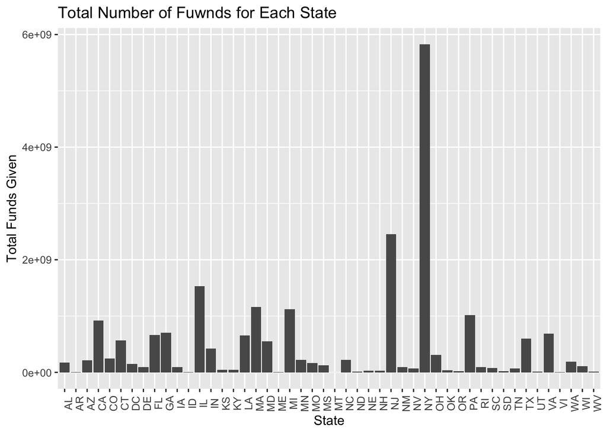

## **CHART 2**:

This scatter plot the spikes in data. As time goes by, cases increase but the number of deaths are slowly flattening out which means that vaccinations, mandates, and other precautions have reduced the death-risk of COVID-19 though the cases have continued to increase. This is important in answering the question on how COVID-19 has been changing over time. This graph shows that some progress has been being made as the death rates have decreased over time, emphasizes still that more preventative measures must be taken as the case rates are still increasing.

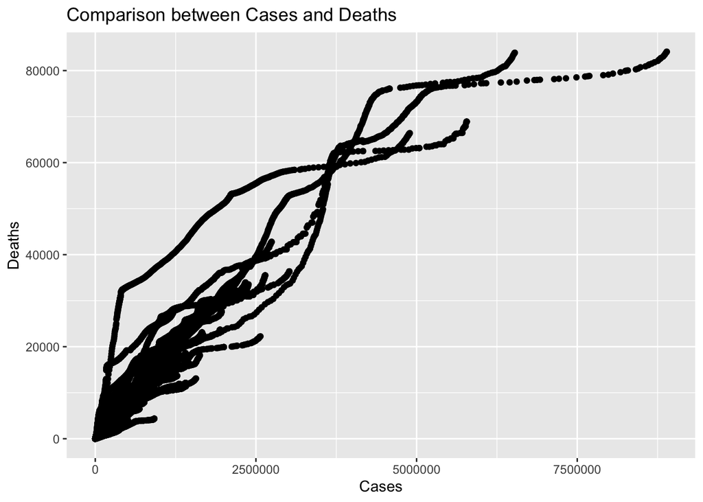